# 사과의 형이상학

이브 × 뉴턴 × 세잔 × 스피노자 — 서양 문명은 왜 사과에 집착하는가

Author

Insight Lab

Published

May 2, 2026

## 1 사과 하나에 문명이 들어 있다

서양 문명사에서 가장 많이 등장하는 과일이 뭔지 생각해본 적 있는가?

포도? 아니다. 올리브? 아니다. **사과**다.

그런데 이상하지 않은가. 사과는 그냥 과일이다. 우리에게 사과는 부사, 홍옥, 아오리 — 후르츠(fruit)다. 까서 먹는 거다.

하지만 서양 사람들에게 사과는 **진리와 선악 사이에 놓인 메타포**다. 한 입 베어 물면 세상이 바뀐다. 네 번 바뀌었다.

## 2 첫 번째 사과: 이브 — “알겠다”는 선택의 대가

**Note**

**크로스오버**: 신학 × 인식론

창세기의 그 장면. 뱀이 말한다: “이것을 먹으면 눈이 밝아져 선악을 알게 된다.” 이브가 먹는다. 아담도 먹는다. 그리고 에덴에서 추방된다.

여기서 핵심은 사과가 아니다. 핵심은 **“알겠다(to know)”는 행위에 대가가 있다**는 구조다.

- 모르는 상태 = 낙원
- 아는 상태 = 추방

서양 문명의 가장 깊은 곳에 이 구조가 있다: **앎에는 반드시 고통이 따른다.** 그리스 비극도 같은 구조다. 오이디푸스가 진실을 알게 되는 순간, 눈을 찌른다.

그런데 흥미로운 점: 이브는 **후회하지 않는다.** 성경 어디에도 이브가 “먹지 말걸”이라고 말하는 대목은 없다. 인류 최초의 선택은 — 고통을 알면서도 앎을 택한 것이다.

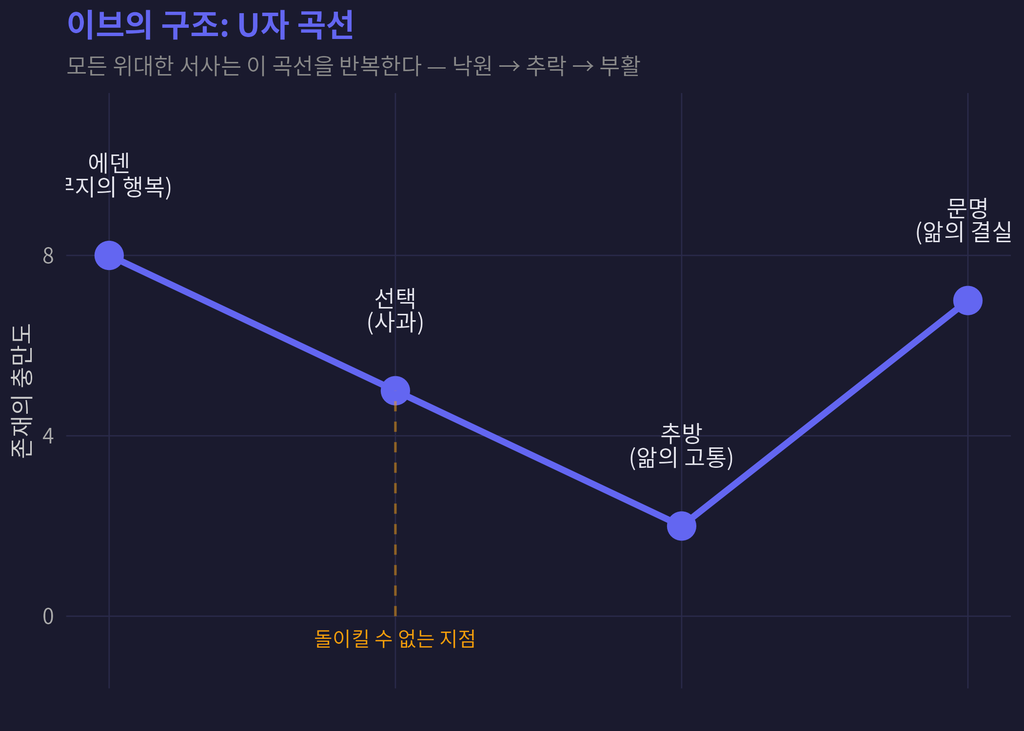

이브의 선택 구조 — 모든 서양 서사의 원형

## 3 두 번째 사과: 뉴턴 — “왜?”라고 묻는 행위

**Note**

**크로스오버**: 물리학 × 인식론

1666년, 울스소프 매너의 정원. 사과가 떨어진다. 뉴턴이 묻는다: “왜 옆으로 가지 않고 아래로 떨어지지?”

이 질문이 웃긴 이유: **모든 사람이 봤지만, 아무도 묻지 않았다.** 사과는 수만 년간 떨어졌다. 모든 인류가 그걸 봤다. 하지만 “왜 아래로?”라고 물은 사람은 없었다.

이브의 사과가 “알겠다”의 대가라면, 뉴턴의 사과는 “왜?”라고 묻는 용기다.

그리고 여기서 결정적 차이 — 이브는 대가를 치렀지만, 뉴턴은 **보상**을 받았다. 중력을 발견했다. 천체의 운동을 설명했다. 근대 과학이 시작되었다.

서양 문명사의 반전: **이브 때는 앎에 벌을 줬는데, 뉴턴 때는 앎에 보상을 준다.** 이 전환 — 앎이 죄에서 미덕으로 바뀌는 전환 — 이것이 과학혁명의 본질이다.

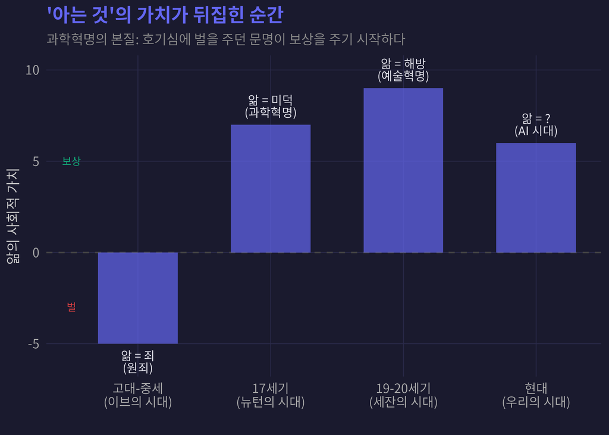

앎의 위상 전환 — 죄에서 미덕으로

## 4 세 번째 사과: 세잔 — “존재 전체를 보겠다”는 욕망

**Note**

**크로스오버**: 미술사 × 위상수학

폴 세잔. 사과를 평생 그린 남자.

“사과 그림이 뭐 대단해?” — 이것은 한국인으로서 당연한 반응이다. 나도 처음엔 그렇게 생각했다. 흐릿하게 사과 그린 거잖아. 뭐?

하지만 세잔이 한 것을 이해하면 — 와, 졌다.

그 이전의 모든 화가: 사과를 **한 방향에서** 그렸다. 원근법(소실점)에 의해. 관찰자의 한 위치에서 본 모습만.

세잔: 사과를 **모든 방향에서 동시에** 그리려 했다. 왼쪽에서 본 것, 오른쪽에서 본 것, 위에서 본 것을 **하나의 캔버스**에. 존재 전체를 2차원에 담으려는 시도.

말도 안 되는 시도다. **그런데 평생 그것만 했다.**

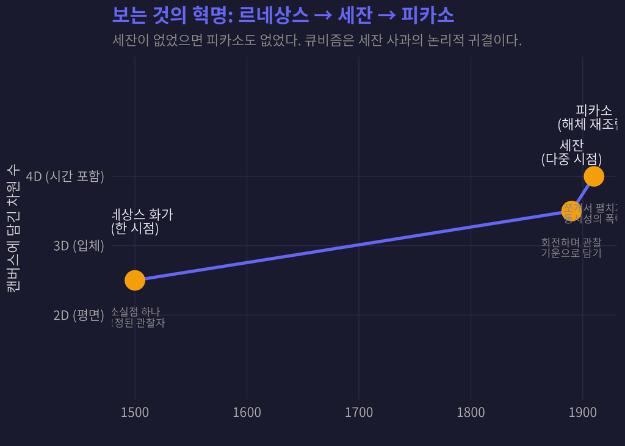

세잔의 사과 — 원근법을 파괴한 시도의 구조

왜 이것이 중요한가?

세잔의 사과는 이런 질문이다: **“보이는 것만이 진실인가?”** 원근법은 한 위치에서 본 것만 진실이라고 선언한다. 세잔은 그것에 반란을 일으켰다. “나는 사과의 존재 전체를 그리고 싶다.”

이것은 곧 양자역학의 문제이기도 하다: 전자는 관찰하면 입자이고, 관찰하지 않으면 파동이다. “한 시점에서 본 것”은 존재의 일부일 뿐이다. 세잔은 물리학보다 30년 먼저 이것을 직감했다.

## 5 네 번째 사과: 스피노자 — “그래도 심겠다”

**Note**

**크로스오버**: 정치철학 × 존재론

> “내일 지구의 종말이 오더라도, 나는 오늘 사과나무를 심겠다.”

이 문장이 스피노자의 것인지 루터의 것인지는 학자들도 논쟁한다. 하지만 스피노자에게 귀속되는 데는 이유가 있다.

스피노자는 1656년 유대인 공동체에서 파문당했다. 23세. “영원한 저주”를 선고받았다. 그 뒤로 렌즈를 깎으며 생계를 유지하고, 《에티카》를 썼다. 살아있는 동안 출판하지 못했다. 죽은 뒤에야 세상에 나왔다.

이 남자에게 “사과나무를 심겠다”는 것은 무엇인가?

**결과를 보지 못할 것을 알면서도 시작하는 행위.** 사과나무는 심은 뒤 열매가 열리기까지 5~8년이 걸린다. 내일 종말이면 열매를 볼 수 없다. 그런데도 심는다.

왜?

스피노자의 답: **행위의 가치는 결과에 있지 않다. 행위 자체의 필연성에 있다.** 나는 사과나무를 심을 수 있는 존재이므로 심는다. 종말이 오든 안 오든, 그것은 나의 본성(conatus)이다.

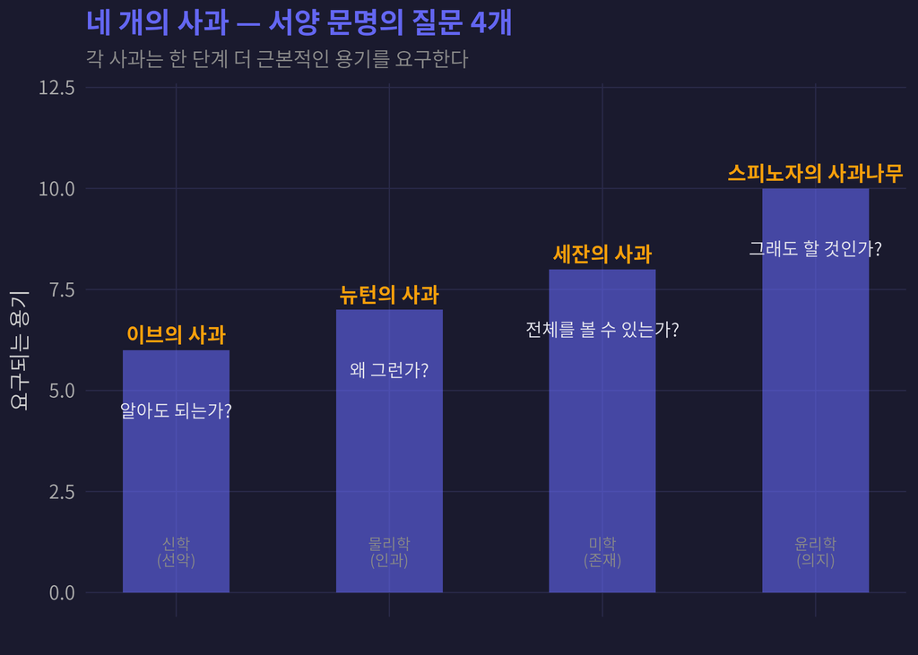

사과 4개의 위치 — 서양 문명의 좌표계

## 6 왜 사과나무인가 — 진짜 답

자, 이제 네 개를 연결하면 구조가 보인다:

| 사과 | 질문 | 답 |
| --- | --- | --- |
| 이브 | 알아도 되는가? | 대가를 치르더라도 — 안다 |
| 뉴턴 | 왜 그런가? | 법칙이 있다 — 찾는다 |
| 세잔 | 전체를 볼 수 있는가? | 보이지 않아도 — 그린다 |
| 스피노자 | 결과 없이도 할 것인가? | 종말이 와도 — 심는다 |

**각 단계가 한 단계 더 근본적인 용기를 요구한다:**

- 1단계: 대가를 알면서 아는 용기 (이브)
- 2단계: 남들이 묻지 않는 것을 묻는 용기 (뉴턴)
- 3단계: 불가능을 알면서 시도하는 용기 (세잔)
- 4단계: 결과를 보지 못할 것을 알면서 시작하는 용기 (스피노자)

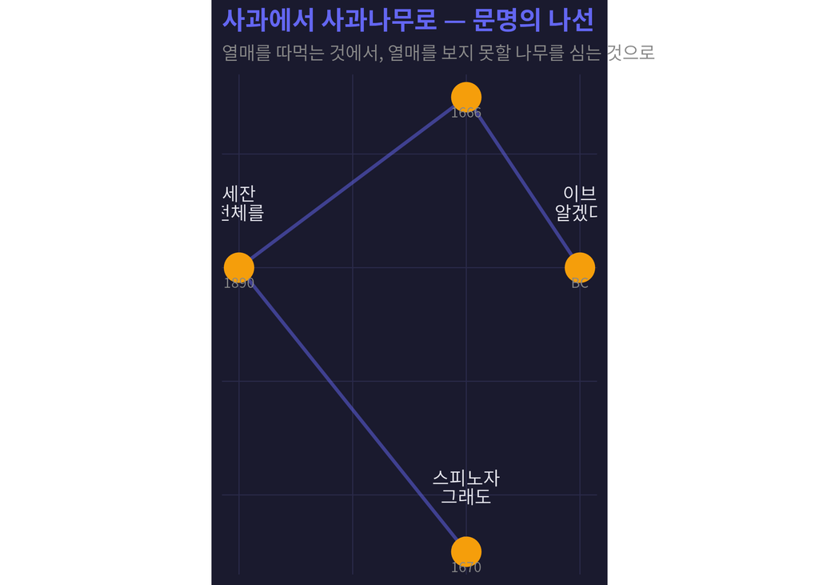

용기의 나선 — 사과에서 사과나무로

## 7 그래서 왜 “사과나무”인가

스피노자가 사과**나무**를 심는다고 말한 것이 결정적이다. 사과가 아니라 사과**나무**를.

이브는 사과를 **땄다.** 뉴턴은 사과가 **떨어지는** 것을 봤다. 세잔은 사과를 **그렸다.** 모두 이미 존재하는 사과에 대한 행위다.

스피노자만이 **아직 존재하지 않는 사과**를 말한다. 나무를 심는 것. 열매가 열리기까지 8년. 내일 종말이면 영원히 열리지 않을 열매.

이것이 서양 문명이 사과에 집착하는 이유의 완성이다:

> **문명이란, 자기가 열매를 보지 못할 나무를 심는 행위의 총합이다.**

앤디 듀프레인이 19년간 벽을 팠듯이. 세잔이 평생 사과만 그렸듯이. 스피노자가 《에티카》를 살아서 출판하지 못할 줄 알면서 썼듯이.

우리가 매일 아침 출근하는 것도, 아이를 키우는 것도, 나무를 심는 것도 — 결과를 확신할 수 없는 행위를 그래도 하는 것이다.

그것이 인간이다.

## 8 부록: 동양의 사과는 어디에 있는가

서양에 사과가 있다면, 동양에는 무엇이 있을까?

아마도 **대나무**일 것이다. 비어 있으면서 곧은 것. 결과가 아니라 과정 자체가 의미인 것. “댓잎에 이슬 맺히듯” — 노력하지 않아도 자연히 차오르는 것.

서양의 사과는 항상 **행위**를 요구한다. 따다, 보다, 그리다, 심다. 동양의 대나무는 **비움**을 요구한다.

하지만 그것은 다음 이야기다.

**Tip**

**이번 주의 통찰**: 문명이란 열매를 보지 못할 나무를 심는 행위의 총합이다.

*Insight Lab SP9 | 신학 × 물리학 × 미학 × 정치철학*